# Extended War Report

2026-08-02

# Overview

This is an extended war report for the war **46204** between **Ludus Magnus** and **Torn Community Garden**. Data is presented from the side of **Torn Community Garden**. Link to the official war report can be found [HERE](https://www.torn.com/war.php?step=rankreport&rankID=46204).

## Rewards

War outcome for your faction: **Victory**  
Total hits done: **1638**  
War hits: **1215**  
Non war hits: **423**  
Total respect earned: **13716.05**  
Members contributed: **54/62**

Rewards for your faction:

| Name | Amount | Price |
| --- | --- | --- |
| Armor Cache | 4 | 1.11 B |
| Medium Arms Cache | 4 | 714.67 M |
| Heavy Arms Cache | 1 | 379.94 M |
| Small Arms Cache | 1 | 113.52 M |

Earnings from caches: **2.32 B**  
Total earnings: **2.32 B**<sup>1</sup>

<sup>1</sup>prices are based on market value or approximate trader prices if market value is unavaliable.

## War Preparation

**NOTE**: Faction Xanax might be different from Prep Xanax due to how personal stats are calculated. In this case, Faction Xanax is more accurate.

Members who **did not stack** energy before war:

|  | Name | Prep_Xanax | Faction_Xanax | Total_Hits |
| --- | --- | --- | --- | --- |
| 1 | Alchemist-Ifrit | 3 | 3 | 33 |
| 2 | Ch3wie | 2 |  | 0 |
| 3 | Elmoz | 3 | 2 | 47 |
| 4 | Jannerboy | 3 | 3 | 3 |
| 5 | PsychePlays | 0 |  | 0 |
| 6 | morango | 0 |  | 0 |

Members who **overdosed** during war preparations (but could still have stacked):

|  | Name | Prep_Xanax | Faction_Xanax | Total_Hits |
| --- | --- | --- | --- | --- |
| 1 | Anonymoose | 5 | 2 | 24 |
| 2 | ClydeXxX | 5 |  | 4 |
| 3 | Ezza | 7 | 7 | 31 |
| 4 | FogBorne | 4 | 3 | 5 |
| 5 | Marika | 5 |  | 22 |
| 6 | ScatterBean | 5 | 6 | 27 |
| 7 | cutt | 5 | 5 | 49 |

Members who **most likely stacked** energy before war (or just used lots of xanax):

|  | Name | Prep_Xanax | Faction_Xanax | Total_Hits |
| --- | --- | --- | --- | --- |
| 1 | -Antheia- | 8 | 8 | 45 |
| 2 | Anonculus | 5 | 2 | 18 |
| 3 | Anthrax132 | 6 | 4 | 29 |
| 4 | Ayepeks | 8 |  | 0 |
| 5 | BakedBeanSoup | 6 | 4 | 0 |
| 6 | BillTheImpaler | 7 | 5 | 30 |
| 7 | BlackLab | 5 | 5 | 58 |
| 8 | Brenadryl | 9 | 9 | 55 |
| 9 | Chapelle | 4 | 3 | 1 |
| 10 | DarkCupidsBow | 7 | 7 | 37 |

[output cut: 39 more lines]

## Fighting summary

### Top 5

Top 5 by overall contribution %

| Name | Contribution |
| --- | --- |
| OliverDerGamer | 5.07 |
| Supreme_ | 4.82 |
| Zoot | 4.15 |
| SwiggitySwooty | 3.72 |
| BlackLab | 3.54 |

Top 5 by War hits

| Name | War_Hits |
| --- | --- |
| Brenadryl | 55 |
| Zoot | 49 |
| dorie | 47 |
| Elmoz | 46 |
| Psyp | 46 |

Top 5 by Non War hits

| Name | Non_War_Hits |
| --- | --- |
| Supreme_ | 71 |
| OliverDerGamer | 58 |
| -Antheia- | 45 |
| cutt | 41 |
| SirDabachuu | 29 |

Top 5 by Total hits

| Name | Total_Hits |
| --- | --- |
| OliverDerGamer | 83 |
| Supreme_ | 79 |
| Zoot | 68 |
| SwiggitySwooty | 61 |
| BlackLab | 58 |

Top 5 by Assists

| Name | Assists |
| --- | --- |
| Ezza | 30 |
| Brenadryl | 26 |
| miel | 24 |
| UnicornKitty | 23 |
| Ptidibou | 17 |

Chain savers - List of people who saved the chain with less than 60 seconds remaining.

```
## [1] "Friendly chain savers:"
```

| Saver | Chain | Time remaining |
| --- | --- | --- |
| OliverDerGamer | 672 | 58 |
| MagioMatt | 521 | 27 |
| SwiggitySwooty | 494 | 56 |
| Nuit | 433 | 43 |
| Ptidibou | 403 | 33 |
| SwiggitySwooty | 400 | 58 |
| Anthrax132 | 376 | 15 |
| Vinefrost | 357 | 43 |
| Supreme_ | 339 | 29 |
| Thomith | 213 | 27 |
| Pearl | 161 | 39 |
| GxSlade | 160 | 14 |
| Elmoz | 159 | 35 |
| BlackLab | 158 | 39 |
| Ptidibou | 157 | 34 |
| GxSlade | 152 | 57 |
| BlackLab | 143 | 60 |
| Elmoz | 138 | 50 |
| Elmoz | 134 | 55 |
| Elmoz | 132 | 55 |
| Kronosphere | 122 | 54 |
| GxSlade | 121 | 49 |
| UnicornKitty | 117 | 20 |
| UnicornKitty | 116 | 20 |
| Violet | 113 | 37 |
| UnicornKitty | 112 | 18 |
| SwiggitySwooty | 111 | 43 |
| Zoot | 107 | 25 |
| Psyp | 104 | 7 |
| Violet | 100 | 11 |
| Violet | 99 | 33 |
| Violet | 95 | 45 |
| Violet | 94 | 31 |
| SwiggitySwooty | 86 | 50 |
| Psyp | 80 | 23 |
| Violet | 76 | 29 |
| Violet | 74 | 38 |
| Psyp | 69 | 18 |
| Violet | 69 | 49 |
| The_Totem | 65 | 13 |
| Violet | 63 | 30 |
| Violet | 43 | 38 |
| Psyp | 30 | 9 |
| Zoot | 27 | 47 |

```
## [1] "No enemy chain saves found!"
```

### Visual summary

Only including members with non-zero contribution

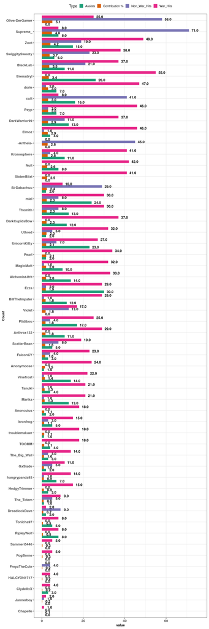

### Respect

Respect earned by each member.<sup>1</sup>  
Total respect earned: **13716.05**  
Total respect lost: **348.51**  
Net respect change: **13367.54**<sup>2</sup>  
Average respect earned per attack: **7.21**

<sup>1</sup>Chain bonuses are ignored in per-member contributions.  
<sup>2</sup>Respect lost will be 0 if using non-faction API key.

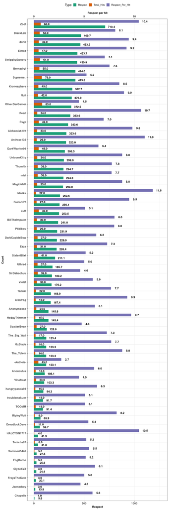

### War Score

Looking at war score gained and lost by each member.  
**The calculations IGNORE chain bonuses in order to better reflect actual contribution rather than landing a lucky hit**  
Total score earned: **10155.51**  
Total score lost: **1174.37**<sup>1</sup>  
Median net score per member: **104.68**<sup>2</sup>

<sup>1</sup>Score lost will be 0 if using non-faction API key.  
<sup>2</sup>Using median instead of mean to avoid extreme values skewing the metric.

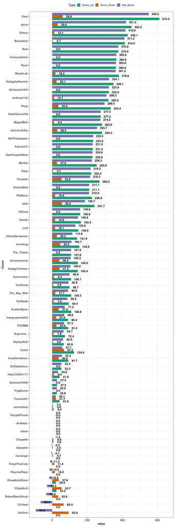

### Slackers

Members who did not meet 1% contribution cutoff

| Name | Contribution |
| --- | --- |
| GxSlade | 0.98 |
| HedgyTrimmer | 0.92 |
| hangrypanda93 | 0.92 |
| The_Totem | 0.85 |
| DreadlockDave | 0.67 |
| RipleyWolf | 0.49 |
| Tonicha97 | 0.49 |
| FogBorne | 0.31 |
| Sammeri5446 | 0.31 |
| ClydeXxX | 0.24 |
| HALCYON1717 | 0.24 |
| FreyaTheCute | 0.24 |
| Jannerboy | 0.18 |
| Chapelle | 0.06 |
| mlem | 0.00 |
| Ch3wie | 0.00 |
| BakedBeanSoup | 0.00 |
| Sottom | 0.00 |
| FalujahFrank | 0.00 |
| Ayepeks | 0.00 |
| morango | 0.00 |
| PsychePlays | 0.00 |

### Energy

Summary of who wasted the most energy and who cost the enemy the most energy.  
Calculated by adding up Losses (and Stalemates, Defends, Escapes, Interrupts) and Defends, the multiplying the number by 25.  
E_Wasted means the member spent X energy on attacks that failed.  
E_Stolen means X energy was wasted by the enemy on attacking the member unsuccessfully.  
You might want to take a closer look at members with high E_Wasted values and remind them to pick fights they can win!

<sup>1</sup> These numbers will be 0 if you are using an API key WITHOUT faction access.

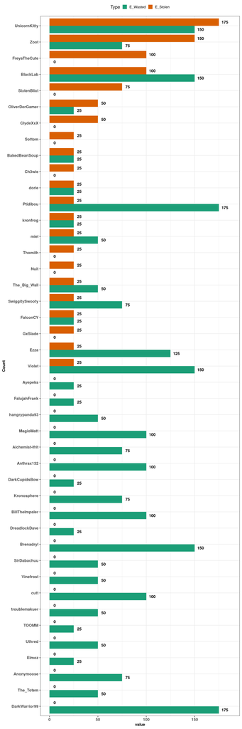

### Full table

Full table with filters and search

|  | Name | Total_Hits | Contribution | War_Hits | Non_War_Hits | Assists | Respect | Respect_Per_Hit | Respect_Lost | Score_Up | Score_Down | Net_Score |
| --- | --- | --- | --- | --- | --- | --- | --- | --- | --- | --- | --- | --- |
| 1 | Violet | 30 | 1.83 | 17 | 13 | 0 | 176.18 | 5.87 | 17.65 | 124.89 | 67.22 | 57.67 |
| 2 | DarkWarrior99 | 48 | 2.93 | 37 | 11 | 13 | 308.52 | 6.43 | 0 | 277.05 | 0 | 277.05 |
| 3 | Pearl | 34 | 2.08 | 34 | 0 | 2 | 363.5599999999999 | 10.69 | 0 | 363.5599999999999 | 0 | 363.56 |
| 4 | HedgyTrimmer | 15 | 0.92 | 15 | 0 | 3 | 145.36 | 9.69 | 10.85 | 145.36 | 41.34 | 104.02 |
| 5 | Ezza | 31 | 1.89 | 29 | 2 | 30 | 226.42 | 7.3 | 0.92 | 222.89 | 3.66 | 219.23 |
| 6 | Zoot | 68 | 4.15 | 49 | 19 | 15 | 710.35 | 10.45 | 14.95 | 610.3800000000002 | 59.85 | 550.53 |
| 7 | The_Totem | 14 | 0.85 | 9 | 5 | 1 | 123.26 | 8.8 | 0.88 | 107.8 | 0 | 107.8 |
| 8 | Anonymoose | 24 | 1.47 | 24 | 0 | 1 | 145.76 | 6.07 | 10.12 | 145.76 | 40.41000000000001 | 105.35 |
| 9 | Elmoz | 47 | 2.87 | 46 | 1 | 4 | 433.74 | 9.23 | 3.56 | 430.09 | 12.11 | 417.98 |
| 10 | GxSlade | 16 | 0.98 | 11 | 5 | 2 | 123.27 | 7.7 | 1.98 | 94.42999999999999 | 7.91 | 86.52 |

[output cut: 52 more lines]

## Extra details

### Xanax and refill usage

Xanax and Energy refill usage during the war.

Total Xanax used: **189**  
Xanax costs: **157.22 M**  
Total Refills used: **55**  
Refill costs: **42.94 M**

Drug cost in plot is in millions.

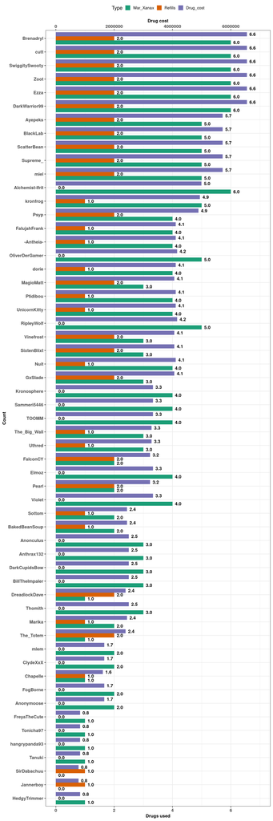

### Booster and can usage

Energy can and Booster usage during the war.

Total Boosters used: **5**  
Booster costs: **67.09 M**  
Total Cans used: **65**  
Can costs: **130.52 M**

All Boosters are assumed to be FHCs and Can price is set to average market value for ALL cans.

Booster cost in plot is in 10s of millions.

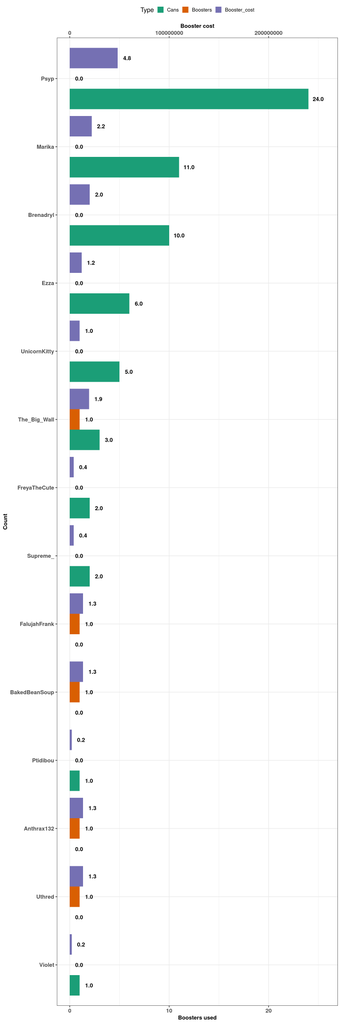

### Armory usage (BETA)

This is a summary of Armory usage during the preparation and war period.  
It can be useful for getting a good idea of how much consumables were used during the war in total.

<sup>1</sup> This section will be empty if you are using an API key WITHOUT faction access.

#### During preparation

```
## [1] "Preparation Armory usage:"
```

|  | Name | ID | action | amount | item | Hours_to_war |
| --- | --- | --- | --- | --- | --- | --- |
| 1 | BakedBeanSoup | 4199880 | used | 1 | Bottle of Beer | 71.92 |
| 2 | BakedBeanSoup | 4199880 | used | 1 | Bottle of Beer | 71.92 |
| 3 | BakedBeanSoup | 4199880 | used | 1 | Bottle of Beer | 71.92 |
| 4 | BakedBeanSoup | 4199880 | used | 1 | Bottle of Beer | 71.92 |
| 5 | BakedBeanSoup | 4199880 | used | 1 | Bottle of Beer | 71.92 |
| 6 | BakedBeanSoup | 4199880 | used | 1 | Bottle of Beer | 71.92 |
| 7 | BakedBeanSoup | 4199880 | used | 1 | Bottle of Beer | 71.92 |
| 8 | BakedBeanSoup | 4199880 | used | 1 | Bottle of Beer | 71.92 |
| 9 | BakedBeanSoup | 4199880 | used | 1 | Bottle of Beer | 71.92 |
| 10 | BakedBeanSoup | 4199880 | used | 1 | Bottle of Beer | 71.92 |

[output cut: 1152 more lines]

```
## [1] "Preparation usage totals:"
```

|  | Action | Item | Count |
| --- | --- | --- | --- |
| 1 | used | Bottle of Beer | 525 |
| 2 | used | Xanax | 244 |
| 3 | loaned | Smoke Grenade | 209 |
| 4 | used | Bag of Chocolate Kisses | 161 |
| 5 | used | Blood Bag : A+ | 76 |
| 6 | loaned | Flash Grenade | 60 |
| 7 | loaned | Tear Gas | 55 |
| 8 | used | Blood Bag : O+ | 31 |
| 9 | loaned | Pepper Spray | 30 |
| 10 | used | First Aid Kit | 23 |

[output cut: 23 more lines]

```
## [1] "Only showing consumables"
```

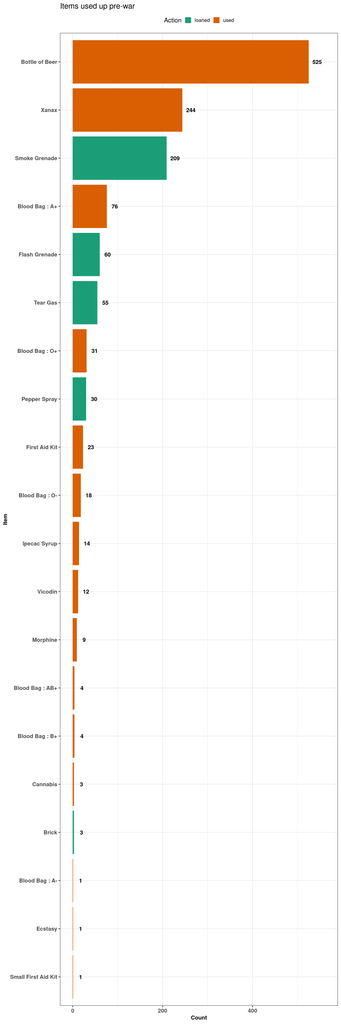

#### During war

```
## [1] "War Armory usage:"
```

|  | Name | ID | action | amount | item | Hours_to_end |
| --- | --- | --- | --- | --- | --- | --- |
| 1 | Anthrax132 | 3940834 | used | 1 | Blood Bag : O+ | 24.66 |
| 2 | Anthrax132 | 3940834 | used | 1 | Blood Bag : O+ | 24.66 |
| 3 | BillTheImpaler | 3683008 | used | 1 | Morphine | 24.66 |
| 4 | BillTheImpaler | 3683008 | used | 1 | Morphine | 24.66 |
| 5 | BillTheImpaler | 3683008 | used | 1 | Morphine | 24.66 |
| 6 | BillTheImpaler | 3683008 | used | 1 | Morphine | 24.66 |
| 7 | BillTheImpaler | 3683008 | used | 1 | Morphine | 24.66 |
| 8 | Pearl | 1630208 | used | 1 | Blood Bag : O+ | 24.66 |
| 9 | Thomith | 2843579 | used | 1 | Blood Bag : O+ | 24.66 |
| 10 | Thomith | 2843579 | used | 1 | Blood Bag : O+ | 24.66 |

[output cut: 759 more lines]

```
## [1] "War usage totals:"
```

|  | Action | Item | Count |
| --- | --- | --- | --- |
| 1 | used | Blood Bag : A+ | 202 |
| 2 | loaned | Tear Gas | 169 |
| 3 | used | Blood Bag : O+ | 125 |
| 4 | loaned | Smoke Grenade | 108 |
| 5 | loaned | Flash Grenade | 65 |
| 6 | loaned | Pepper Spray | 60 |
| 7 | used | Xanax | 57 |
| 8 | used | Bottle of Beer | 57 |
| 9 | used | Morphine | 50 |
| 10 | used | Blood Bag : O- | 47 |

[output cut: 17 more lines]

```
## [1] "Only showing consumables"
```

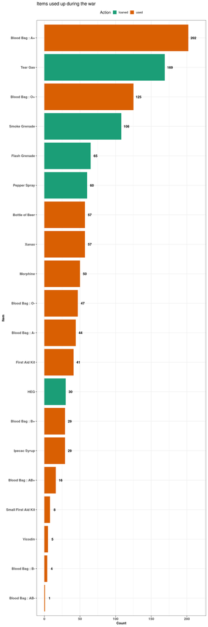

### Activity

Member activity during the war in hours.

```
## [1] "Correlation between activity and contribution:"
```

```
## [1] 0.56
```

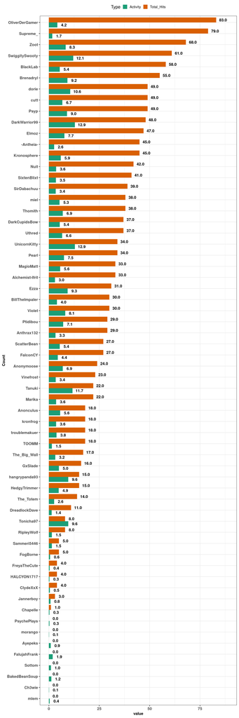

### Hospital

Summary of times hospitalized during the war

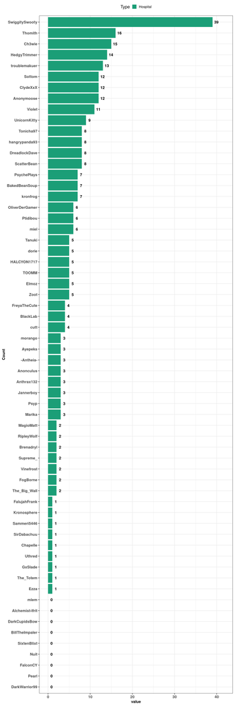

### Full table

|  | Name | War_Xanax | Refills | Boosters | Cans | Drug_cost | Booster_cost | Activity | Hospital |
| --- | --- | --- | --- | --- | --- | --- | --- | --- | --- |
| 1 | Violet | 4 | 0 | 0 | 1 | 3327508 | 2008030.11 | 8.12 | 11 |
| 2 | DarkWarrior99 | 6 | 2 | 0 | 0 | 6552862 | 0 | 12.87 | 0 |
| 3 | Pearl | 2 | 2 | 0 | 0 | 3225354 | 0 | 7.49 | 0 |
| 4 | HedgyTrimmer | 1 | 0 | 0 | 0 | 831877 | 0 | 4.86 | 14 |
| 5 | Ezza | 6 | 2 | 0 | 6 | 6552862 | 12048180.67 | 9.27 | 1 |
| 6 | Zoot | 6 | 2 | 0 | 0 | 6552862 | 0 | 8.29 | 5 |
| 7 | The_Totem | 1 | 2 | 0 | 0 | 2393477 | 0 | 2.59 | 1 |
| 8 | Anonymoose | 2 | 0 | 0 | 0 | 1663754 | 0 | 6.85 | 12 |
| 9 | Elmoz | 4 | 0 | 0 | 0 | 3327508 | 0 | 7.73 | 5 |
| 10 | GxSlade | 3 | 2 | 0 | 0 | 4057231 | 0 | 4.97 | 1 |

[output cut: 52 more lines]

## AI summary (BETA)

This is an experimental portion of the report - an overview of the war generated by AI.  
When looking at this section, keep that in mind and take the results with a grain of salt.  
Before taking any actions that might impact faction members mentioned in this summary, double-check that there are no mistakes or missed key details.

## Post-War Debrief

### 1) Overall Faction Performance

The faction produced a **strong volume of war pressure**, driven by several high-output hitters and a solid core of active participants. Total output was not the issue; **efficiency and consistency were**.

Key positives:

Key concerns:

- There were multiple members with **high activity but low or zero impact**, which dragged down overall conversion of time into progress.
- A noticeable amount of **E_Wasted** appeared across the roster, suggesting poor target selection, failed chains, or inefficient attack sequencing.
- Some of the faction’s Net_Score gains came at a cost of avoidable inefficiency, especially among players with high hit counts but weak efficiency indicators.

Active participation was broad, but not fully optimized. The roster had many contributors, yet a subset of the team generated disproportionate value while others added little beyond presence.

### 2) Team Issues & Strategic Bottlenecks

#### Main systemic issues identified

**1. Energy waste was too widespread**

- Several players showed large **E_Wasted** totals, which is a direct sign of missed opportunities and poor attack selection.
- Some heavy hitters still had inefficient output, meaning raw volume was not always converting into effective war progress.

**2. Activity-to-impact conversion was uneven**

- A number of players had respectable activity durations but weak War_Hits, assists, or net contribution.
- This points to downtime, poor engagement timing, or low-value combat cycles.

**3. Finishing discipline was inconsistent**

- Mugging was present in some cases, but overall there was not enough emphasis on war-appropriate finishing such as **Leave/Hospitalize** when needed.
- Players with high hit counts but excessive wasted energy likely did not prioritize optimal war sequencing.

**4. Some members absorbed damage without meaningful countervalue**

- High Hospital values with low impact or low contribution suggest some members were effectively removed from play without generating enough return.

**5. Contribution imbalance**

- The faction relied heavily on a relatively small group of standout performers.
- This is manageable in the short term, but dangerous in extended wars if those top performers are neutralized.

### 4) Individual Highlights — Negative (Underperformers)

These members either created a points drain, burned energy ineffectively, or contributed too little relative to their activity.

#### Low output relative to presence

- **Chapelle**
  - 1 War_Hits, some hospital time, negative net score
  - Minimal value.
- **Jannerboy**
  - Only 2 War_Hits, low contribution, weak FairFight
  - Not enough output for the position.
- **PsychePlays**
  - 0 War_Hits, 0 contribution, negative net score
  - No war utility.
- **Halcyon1717**
  - 4 War_Hits, modest impact
  - Not harmful, but output was too low for meaningful war pressure.

### 5) Additional Observations

- **High activity with low impact** was a recurring issue. Several players logged measurable activity but failed to convert it into meaningful war contribution.
- A number of players had **very strong assist totals** despite modest War_Hits, which is useful and should be preserved. These members were playing team war, not just chasing personal damage.
- Some of the best war profiles were not the highest raw hitters, but those with:
  - strong **FairFight**
  - high **Assists**
  - low **E_Wasted**
  - meaningful **E_Stolen**
- **Pearl** deserves note as a top-tier war contributor:
  - 34 War_Hits, 0 hospital, 363.56 Net_Score, clean profile
  - Very efficient and reliable.
- **FalconCY** was also highly effective:
  - 23 War_Hits, 25 E_Stolen, clean and stable performance.
- **DarkWarrior99** and **Zoot** were among the strongest war engines by total value delivered.

## Bottom Line

The faction’s war effort was **carried by a strong upper tier of efficient contributors**, while a meaningful portion of the roster either underperformed or produced negative value. The biggest strategic weakness was **inefficient energy use and inconsistent conversion of activity into war progress**.

### Recommended focus for future wars:

1. Reduce **E_Wasted** by tightening target selection and attack discipline.
2. Push more members toward **team-oriented support behavior**: assists, hospitals, and controlled finishing.
3. Protect high-value contributors from becoming overexposed.
4. Reassign or train low-impact members; several are currently roster weight rather than active assets.